# W3cubDocs

/Matplotlib 3.5

# mpl_toolkits.mplot3d.art3d.Poly3DCollection

**class*mpl_toolkits.mplot3d.art3d.Poly3DCollection(*verts*, *args, *zsort='average'*, **kwargs)[[source]](https://github.com/matplotlib/matplotlib/blob/v3.5.1/lib/mpl_toolkits/mplot3d/art3d.py#L677-L888)**

Bases: `matplotlib.collections.PolyCollection`

A collection of 3D polygons.

Note

**Filling of 3D polygons**

There is no simple definition of the enclosed surface of a 3D polygon unless the polygon is planar.

In practice, Matplotlib fills the 2D projection of the polygon. This gives a correct filling appearance only for planar polygons. For all other polygons, you'll find orientations in which the edges of the polygon intersect in the projection. This will lead to an incorrect visualization of the 3D area.

If you need filled areas, it is recommended to create them via `plot_trisurf`, which creates a triangulation and thus generates consistent surfaces.

**Parameters**

**verts**list of (N, 3) array-like**

Each element describes a polygon as a sequence of `N_i` points `(x, y, z)`.

**zsort**{'average', 'min', 'max'}, default: 'average'**

The calculation method for the z-order. See `set_zsort` for details.

**args, **kwargs**

All other parameters are forwarded to `PolyCollection`.

#### Notes

Note that this class does a bit of magic with the _facecolors and _edgecolors properties.

**do_3d_projection(*renderer=<deprecated parameter>*)[[source]](https://github.com/matplotlib/matplotlib/blob/v3.5.1/lib/matplotlib/_api/deprecation.py#L789-L857)**

Perform the 3D projection for this object.

**get_edgecolor()[[source]](https://github.com/matplotlib/matplotlib/blob/v3.5.1/lib/mpl_toolkits/mplot3d/art3d.py#L887-L888)**

**get_facecolor()[[source]](https://github.com/matplotlib/matplotlib/blob/v3.5.1/lib/mpl_toolkits/mplot3d/art3d.py#L884-L885)**

**get_vector(*segments3d*)[[source]](https://github.com/matplotlib/matplotlib/blob/v3.5.1/lib/mpl_toolkits/mplot3d/art3d.py#L746-L756)**

Optimize points for projection.

**set(*, *agg_filter=<UNSET>*, *alpha=<UNSET>*, *animated=<UNSET>*, *antialiased=<UNSET>*, *array=<UNSET>*, *capstyle=<UNSET>*, *clim=<UNSET>*, *clip_box=<UNSET>*, *clip_on=<UNSET>*, *clip_path=<UNSET>*, *cmap=<UNSET>*, *color=<UNSET>*, *edgecolor=<UNSET>*, *facecolor=<UNSET>*, *gid=<UNSET>*, *hatch=<UNSET>*, *in_layout=<UNSET>*, *joinstyle=<UNSET>*, *label=<UNSET>*, *linestyle=<UNSET>*, *linewidth=<UNSET>*, *norm=<UNSET>*, *offset_transform=<UNSET>*, *offsets=<UNSET>*, *path_effects=<UNSET>*, *paths=<UNSET>*, *picker=<UNSET>*, *pickradius=<UNSET>*, *rasterized=<UNSET>*, *sizes=<UNSET>*, *sketch_params=<UNSET>*, *snap=<UNSET>*, *sort_zpos=<UNSET>*, *transform=<UNSET>*, *url=<UNSET>*, *urls=<UNSET>*, *verts=<UNSET>*, *verts_and_codes=<UNSET>*, *visible=<UNSET>*, *zorder=<UNSET>*, *zsort=<UNSET>*)[[source]](https://github.com/matplotlib/matplotlib/blob/v3.5.1/lib/matplotlib/artist.py#L116-L116)**

Set multiple properties at once.

Supported properties are

| Property | Description |
| --- | --- |
| `agg_filter` | a filter function, which takes a (m, n, 3) float array and a dpi value, and returns a (m, n, 3) array |
| `alpha` | unknown |
| `animated` | bool |
| `antialiased` or aa or antialiaseds | bool or list of bools |
| `array` | array-like or None |
| `capstyle` | `CapStyle` or {'butt', 'projecting', 'round'} |
| `clim` | (vmin: float, vmax: float) |
| `clip_box` | `Bbox` |
| `clip_on` | bool |
| `clip_path` | Patch or (Path, Transform) or None |
| `cmap` | `Colormap` or str or None |
| `color` | color or list of rgba tuples |
| `edgecolor` or ec or edgecolors | unknown |
| `facecolor` or facecolors or fc | unknown |
| `figure` | `Figure` |
| `gid` | str |
| `hatch` | {'/', '\', '\|', '-', '+', 'x', 'o', 'O', '.', '*'} |
| `in_layout` | bool |
| `joinstyle` | `JoinStyle` or {'miter', 'round', 'bevel'} |
| `label` | object |
| `linestyle` or dashes or linestyles or ls | str or tuple or list thereof |
| `linewidth` or linewidths or lw | float or list of floats |
| `norm` | `Normalize` or None |
| `offset_transform` | `Transform` |
| `offsets` | (N, 2) or (2,) array-like |
| `path_effects` | `AbstractPathEffect` |
| `paths` | list of array-like |
| `picker` | None or bool or float or callable |
| `pickradius` | float |
| `rasterized` | bool |
| `sizes` | ndarray or None |
| `sketch_params` | (scale: float, length: float, randomness: float) |
| `snap` | bool or None |
| `sort_zpos` | unknown |
| `transform` | `Transform` |
| `url` | str |
| `urls` | list of str or None |
| `verts` | unknown |
| `verts_and_codes` | unknown |
| `visible` | bool |
| `zorder` | float |
| `zsort` | {'average', 'min', 'max'} |

**set_3d_properties()[[source]](https://github.com/matplotlib/matplotlib/blob/v3.5.1/lib/mpl_toolkits/mplot3d/art3d.py#L773-L782)**

**set_alpha(*alpha*)[[source]](https://github.com/matplotlib/matplotlib/blob/v3.5.1/lib/mpl_toolkits/mplot3d/art3d.py#L869-L882)**

Set the alpha value used for blending - not supported on all backends.

**Parameters**

**alpha**array-like or scalar or None**

All values must be within the 0-1 range, inclusive. Masked values and nans are not supported.

**set_edgecolor(*colors*)[[source]](https://github.com/matplotlib/matplotlib/blob/v3.5.1/lib/mpl_toolkits/mplot3d/art3d.py#L864-L867)**

Set the edgecolor(s) of the collection.

**Parameters**

**c**color or list of colors or 'face'**

The collection edgecolor(s). If a sequence, the patches cycle through it. If 'face', match the facecolor.

**set_facecolor(*colors*)[[source]](https://github.com/matplotlib/matplotlib/blob/v3.5.1/lib/mpl_toolkits/mplot3d/art3d.py#L859-L862)**

Set the facecolor(s) of the collection. *c* can be a color (all patches have same color), or a sequence of colors; if it is a sequence the patches will cycle through the sequence.

If *c* is 'none', the patch will not be filled.

**Parameters**

**c**color or list of colors**

**set_sort_zpos(*val*)[[source]](https://github.com/matplotlib/matplotlib/blob/v3.5.1/lib/mpl_toolkits/mplot3d/art3d.py#L784-L787)**

Set the position to use for z-sorting.

**set_verts(*verts*, *closed=True*)[[source]](https://github.com/matplotlib/matplotlib/blob/v3.5.1/lib/mpl_toolkits/mplot3d/art3d.py#L758-L763)**

Set 3D vertices.

**set_verts_and_codes(*verts*, *codes*)[[source]](https://github.com/matplotlib/matplotlib/blob/v3.5.1/lib/mpl_toolkits/mplot3d/art3d.py#L765-L771)**

Set 3D vertices with path codes.

**set_zsort(*zsort*)[[source]](https://github.com/matplotlib/matplotlib/blob/v3.5.1/lib/mpl_toolkits/mplot3d/art3d.py#L732-L744)**

Set the calculation method for the z-order.

**Parameters**

**zsort**{'average', 'min', 'max'}**

The function applied on the z-coordinates of the vertices in the viewer's coordinate system, to determine the z-order.

## Examples using `mpl_toolkits.mplot3d.art3d.Poly3DCollection`

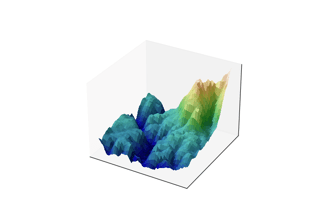

[Frontpage 3D example](https://matplotlib.org/3.5.1/gallery/frontpage/3D.html#sphx-glr-gallery-frontpage-3d-py)

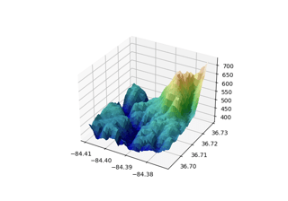

[Custom hillshading in a 3D surface plot](https://matplotlib.org/3.5.1/gallery/mplot3d/custom_shaded_3d_surface.html#sphx-glr-gallery-mplot3d-custom-shaded-3d-surface-py)

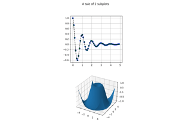

[2D and 3D Axes in same Figure](https://matplotlib.org/3.5.1/gallery/mplot3d/mixed_subplots.html#sphx-glr-gallery-mplot3d-mixed-subplots-py)

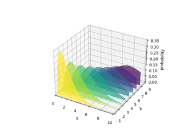

[Generate polygons to fill under 3D line graph](https://matplotlib.org/3.5.1/gallery/mplot3d/polys3d.html#sphx-glr-gallery-mplot3d-polys3d-py)

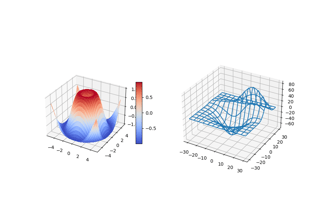

[3D plots as subplots](https://matplotlib.org/3.5.1/gallery/mplot3d/subplot3d.html#sphx-glr-gallery-mplot3d-subplot3d-py)

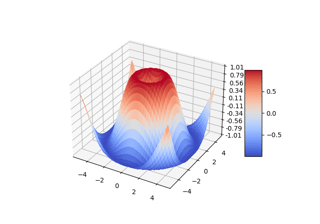

[3D surface (colormap)](https://matplotlib.org/3.5.1/gallery/mplot3d/surface3d.html#sphx-glr-gallery-mplot3d-surface3d-py)

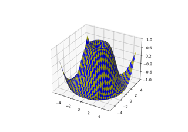

[3D surface (checkerboard)](https://matplotlib.org/3.5.1/gallery/mplot3d/surface3d_3.html#sphx-glr-gallery-mplot3d-surface3d-3-py)

© 2012–2021 Matplotlib Development Team. All rights reserved.  
Licensed under the Matplotlib License Agreement.  
https://matplotlib.org/3.5.1/api/_as_gen/mpl_toolkits.mplot3d.art3d.Poly3DCollection.html